# U1. La economía del sector público

Finanzas Públicas [Cat. Barraud]

Sebastian Freille

Universidad Nacional de Córdoba

# Bibliografía

- Stiglitz, J. E. (2000). La Economia del Sector Público (3ra. edición), Barcelona: Antoni Bosch Editor. Capítulo 1, págs. 11-34.
- Albi, E. González-Páramo, J.M. y Zubiri, I. (2009). Economía Pública (3ra. edición), Barcelona: Ariel. Capítulo 1, págs 3-13
- Musgrave, R. A. and Musgrave, P.B. (1992). Hacienda Pública Teórica y Aplicada (5ta edición), Madrid: Mc-Graw Hill. Capítulo 1, págs. 3-15 y capítulo 4, págs 51-55.
- Garriga, M., & Rosales, W. (2013).Finanzas públicas en la práctica. Selección de casos y aplicaciones. Buenos Aires: Editorial Dunken. Capítulo 1, págs. 10-16.

# **La economía del sector público: Introducción, concepto y alcance**

1. Economía del sector público (ESP)
2. Roles y funciones del Estado
   - Asignación
   - Distribución
   - Estabilización
3. Otros temas

# **Economía del sector público (ESP)**

# ESP: Introducción

- Principales **temas y relevancia** de la economía del sector público
- Motivación y fundamentación de la **intervención del Estado en la economía**
- **Eficiencia y equidad**: dos objetivos (frecuentemente) en pugna

# ESP: Temas de la ESP

Puede pensarse en los dos grandes ejes de la ESP como:

- Efectos de políticas

> ¿Cómo las políticas del gobierno afectan a la economía?
- Diseño de políticas

> ¿Cómo deberían diseñarse las políticas para máximizar el bienestar?

# ESP: ¿Por qué estudiar ESP?

1. Relevancia práctica: casi cualquier intervencón económica ocurre a través de una política del gobierno a través de dos canales:
   1. intervención de precios (impuestos, subsidios)
   2. regulación y normativas (salario minimo, regulaciones ambientales, ley de etiquetado)
2. El gobierno emplea una parte significativa de la población –17% en Argentina, 15% EEUU. Esto en forma directa. Mucho más en forma indirecta

# ESP: Empleo en sector público

[figure not shown]

Empleo en el sector público, varios países

# ESP: ¿Por qué interviene el Estado?

- Mejor aún: ¿Cuándo es necesaria la intervención del Estado en la economía? Consenso teórico:
  - Primero el mercado, sino el Estado
  - ¿Por qué? Resultado del **mercado es eficiente bajo una serie de supuestos** (1TDB)
- Dos preguntas clave:
  - ¿Cómo puede el gobierno **mejorar la eficiencia** cuando el mercado es ineficiente?
  - ¿Qué puede hacer el gobierno para **mejorar la distribución** cuando la distribución del mercado es socialmente indeseable?

# ESP: Eficiencia en mercado

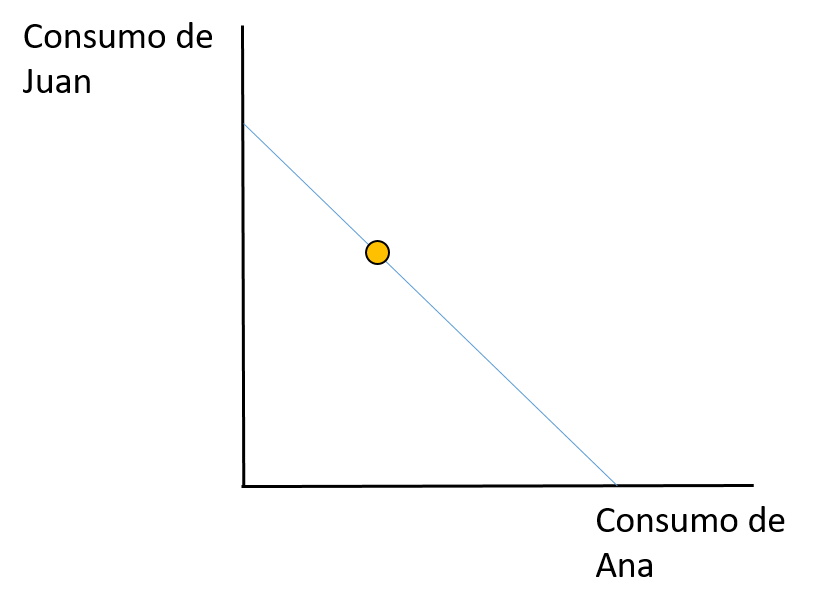

# ESP: Rol #1 - Mejorar eficiencia

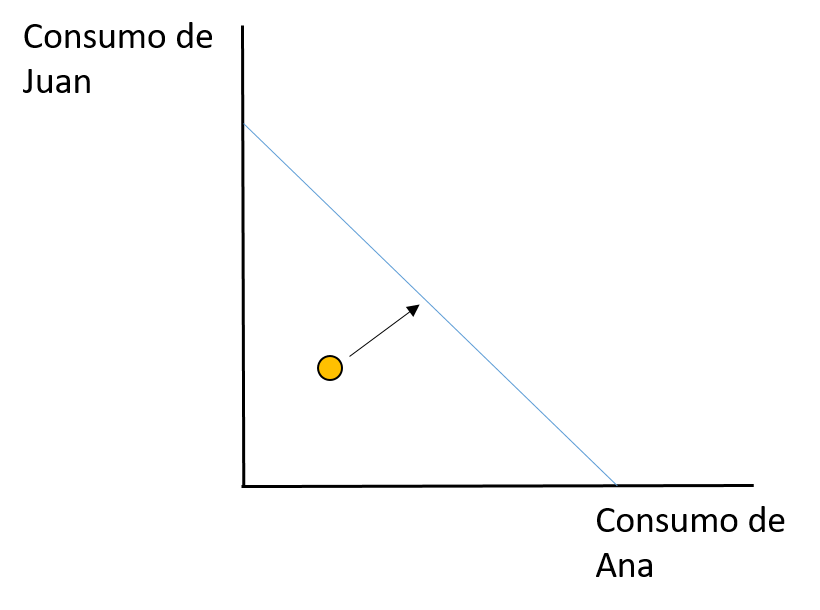

# ESP: Rol #2 - Mejorar distribución

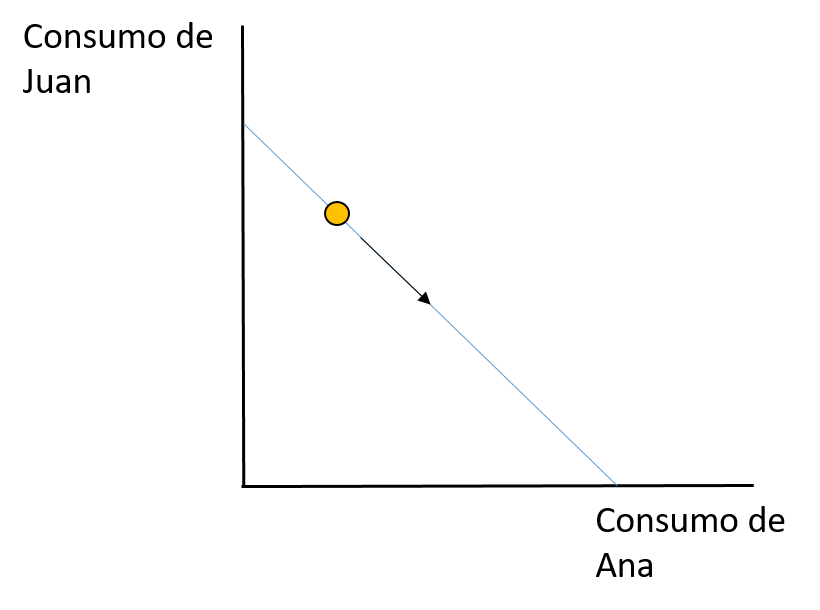

# ESP: ¿Hay algún costo *económico* asociado?

- Si bien proponentes de intervención del Estado argumentan que costos de intervención son menores que beneficios (mejorar eficiencia, mejorar distribución), **la intervención del Estado puede causar distorsiones**.
- Las distorsiones en general surgen por el hecho de que cuando el Estado interviene a través de múltiples herramientas (impuestos, subsidios, regulaciones) es posible que se **modifique la conducta de los agentes económicos**.

# ESP: Mejorar distribución…

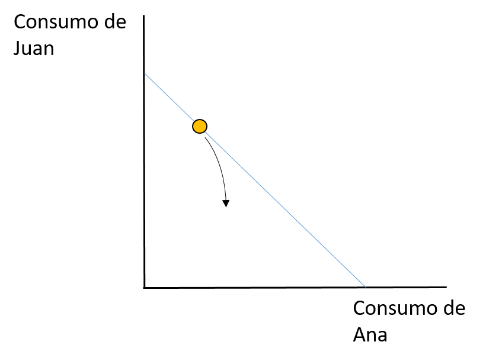

# ESP: …pero empeorar eficiencia!

- Esta asociación entre mejorar distribución y empeorar eficiencia se conoce como **compromiso entre eficiencia y equidad (trade-off eficiencia-equidad)** y está en el núcleo de la intervención del Estado en la economía
- El compromiso se refleja en el hecho que la **respuesta en la conducta de los agentes económicos** ante la intervención del gobierno se materializa en términos económicos!
- Salvo en pocas y contadas excepciones (fundamentalmente curiosidades teóricas) este compromiso siempre está presente

# ESP: ¿Hay almuerzos gratis?

[figure not shown]

# ESP: Fundamentos de la intervención estatal

- Si el mercado no asegura eficiencia. Casos: 1) externalidades, 2) información asimétrica/mercados incompletos y 3) competencia imperfecta
- El resultado del mercado puede ser eficiente aunque no necesariamente conduce a situaciones distributivas aceptadas desde el punto de vista social
- Ante fuertes shocks en los mercados las economías pueden atravesar situaciones de alto desempleo e inflación. Políticas de estímulo

# ESP: Funciones del Estado

Existe una tradicional divisíon de las funciones del Estado en términos económicos:

# **Roles y funciones del Estado**

# **Asignación**

1. Externalidades
2. Recursos de propiedad común (RPC)
3. Bienes públicos
4. Información imperfecta
5. Competencia imperfecta (monopolio y otras formas de mercado)
6. Fallos “individuales”

# Asignación: Externalidades

- Los mercados pueden ser incompletos debido a la falta de precios –i.e contaminación
- El logro de un solución Coasiana de eficiencia requiere de algo que coordine a los individuos –i.e. el Estado
- Esta es la razón por la que el Estado financia bienes públicos
  - Pregunta: ¿Qué bienes públicos proveer y cómo corregir las externalidades?
- En muchos casos, los actos de una persona/empresa afectan a otras personas/empresas; en los que una persona/empresa impone costos a otra pero nos las compensa; en los que una persona/empresa genera un beneficio a otras pero no es compensada –contaminación de aire y agua
- Cuando se imponen costos a tercero/s hablamos de **externalidades negativas**; cuando se generan beneficios a tercero/s hablamos de **externalidades positivas**.
- El punto importante es que siempre que haya actividades económicas que generan este tipo de costos/beneficios, la asignacion que realiza el mercado puede no ser eficiente [¿Por qué?]

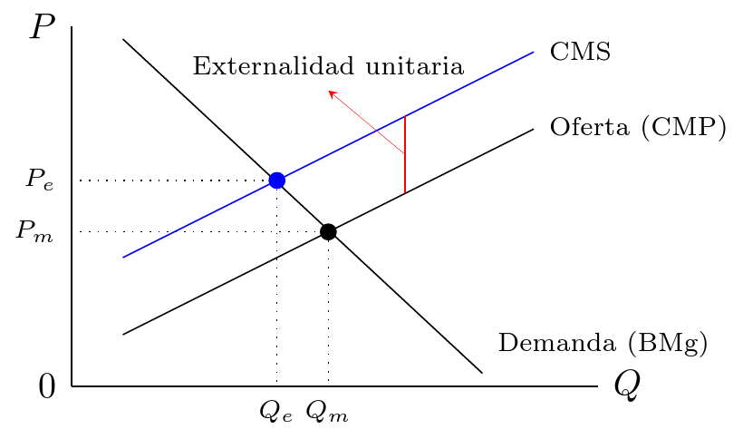

- Se pueden **corregir via legislación** –se definen los derechos de propiedad y si los costos de negociación no son muy altos, el mercado puede corregirlas (teorema de Coase)
- Se pueden **corregir via regulación** –se fijan niveles eficientes de producción/consumo –i.e cuotas
- Se pueden **corregir via la aplicación de impuestos y subsidios** para internalizar la externalidad –impulsa a producir menos de la externalidad negativa y mas de la positiva

# Asignación: Recursos de propiedad común (RPC)

- En 1968, Garrett Hardin publicó un célebre artículo en la revista *Science* llamado [“The Tragedy of the Commons”](https://science.sciencemag.org/content/162/3859/1243).
- Tiene casi 50 mil citaciones reintrodujo una discusión de siglos –como hacer frente al crecimiento poblacional relativo a los recursos y bienes disponibles
- Pero además –y más importante para este curso- introdujo en la discusión el **problema de los recursos de propiedad común (“commons”)**, o también conocida como la tragedia de los bienes comunales.
- Un recurso de propiedad común (RPC) **es un bien/factor a cuyos servicios todo el mundo tiene libre acceso** –bancos de pesca, pastos comunales, ríos, lagos y recursos naturales
- La **falla de mercado** se produce ya que estos bienes tienen costo de explotación directo igual a cero.
- Los usuarios individuales no tienen en cuenta el costo de explotación (y sobreexplotación) del recurso
- Los RPC son en realidad **una forma de externalidad** –ya sea entre empresas y/o individuos. Note que el daño aquí es reducir la cantidad el recurso para el resto de empresas y/o individuos.
- En décadas recientes, muchos autores desafiaron las ideas de Hardin. La más importante fue Elinor Ostrom
- Ostrom argumentó que **las sociedades y los grupos se organizan para diseñar reglas y mecanismos de cumplimiento** para impedir la degradación de los RCP
- Una de sus contribuciones fue cuestionar los modelos pre-existentes –tragedia de los “commons”, dilema del prisionero y la lógica de la acción colectiva.
- Su otra gran contribución fue **explorar soluciones cooperativas al problema de la administración de RPC** y proponer varias reglas plausibles y viables.

# Asignación: Bienes públicos

- Dos vecinas viven en la misma cuadra. Hay alumbrado de calle (un sólo poste) y un vendededor de pan casero pasa hoy. Sólo le queda un pan. ¿Cuál es la diferencia entre el alumbrado de calle y un pan casero? Las vecinas no pueden consumir el pan casero en forma simultánea: si una lo consume, la otra se queda sin pan. Pero ambas vecinas pueden consumir simultáneamente los servicios de iluminación que da el (único!) poste cuando vuelven del trabajo. En el primer caso, hay rivalidad en el consumo y es posible la exclusión del consumo. En el segundo, no. El pan es un bien privado y el alumbrado es un bien público.
- Un individuo (empresa) tiene incentivos a producir pan casero porque puede cobrar un precio por ellos y así generar ingresos extra. ¿Un individuo (empresa) tiene incentivo a “producir” postes y lámparas de alumbrado de calle en el barrio de ambas amigas?
- Existen **ciertos bienes y servicios que no pueden proveerse por el mecanismo de mercado**. En algunos casos, el mercado falla totalmente. En otros, produce un resultado ineficiente.
- Estos bienes y servicios **se denominan** bienes públicos** y requieren de un estudio independiente de los bienes privados por sus características.
- Características principales de los **bienes públicos puros (BPP)**
  1. **No hay rivalidad en el consumo**
  2. **No hay exclusión en el consumo**
- ¿Por qué razón se dice que falla el mercado?
  1. Sería ineficiente cobrar un precio por un bien como el alumbrado públic [¿por qué?]
  2. Sería técnicamente imposible excluir de los beneficios de un bien/servicio a un consumidor [¿por qué?]
- Si los productores no tienen incentivos en *proveer* BPP y los consumidores derivan beneficios de consumir BPP, ¿entonces qué sucedería si lo dejáramos librado al mercado sin intervención del Estado? Dos posibles resultados
  1. Provisión cero
  2. Provisión menor a la óptima

# Asignación: Información imperfecta

- Algunos fallos del mercado provienen del hecho de que existen **asimetrías de información entre diferentes agentes** (consumidores/productores).
- Suele ocurrir que los individuos acuerdan en base a información privada en beneficio propio y en desventaja de la parte menos informada
  1. Mercados privados de seguros
     - Seguros de salud/Seguros de vida
     - Seguros de vivienda y automovil
- Nuevamente aquí el **mercado puede simplemente no existir** (no se desarrolla) o **puede desaparecer/congelarse**.
- Modelo sencillo con **dos tipos de individuos cuya única diferencia es el riesgo**, representado por $p$ –la probabilidad de que el individuo presente un reclamo a la compañía aseguradora
- Los dos tipos de individuos serán entonces, $p_H$ y $p_L$, tal que $p_H > p_L$.
- El individuo conoce su tipo de riesgo pero la compañía aseguradora no [asimetría de información]
- La competencia en el mercado privado de seguros implica la condición de ganacias económicas iguales a cero
- Si los individuos tienen información privada sobre su tipo de riesgo entonces:
  - Tipo de riesgo: enfermarse, perder el trabajo, morir
  - Individuos de alto riesgo tienden a subir el precio de mercado para los de bajo riesgo [¿por qué?]
  - Resultado probable: nadie compra seguros de salud aún cuando el beneficio de tener seguro para cada individuo es mayor al costo de proveerlo a ese individuo
  - Sugiere posibilidad de mejorar bienestar (eficiencia) a través de pagos obligatorios [intervención del Estado]
- Consumidores (demandantes) mejor informados que productores (oferentes)
- Consumidores con bajo riesgo –buena salud- no participan dado alto costo de precio (prima) que llevan hacia arriba consumidores con alto riesgo –mala salud.
- La cantidad producida de seguros de salud es menor a la óptima (incuso puede ser cero)
- Argumento favorable a la intervención del Estado a través de pagos obligatorios y/o regulación similar –seguro obligatorio de vida, de auto, de salud
- Otros ejemplos de fallos de mercado por información imperfecta:
  - Mercado de autos usados
    - Vendedores (oferentes) tienen ventaja de información –conocen el estado de los autos
    - Compradores (demandantes) tienen desventaja de información –no conocen el estado de los autos
  - Mercado de trabajo
    - Trabajadores (oferentes) conocen sus habilidades y su responsabilidad
    - Empresas (demandantes) no conocen las habilidades ni responsabilidad de trabajadores
- Los principales problemas que surgen aquí son los de selección adversa y riesgo moral.

# Asignación: Competencia imperfecta

- Cuando los mercados no son competitivos, puede que sea necesaria la intervención del gobierno.
- Monopolios naturales como los servicios de electricidad y teléfonos –cuando no hay competencia, el mercado produce demasiado poco y a un precio muy alto –el Estado tal vez puede hacerse cargo de producir esos bienes y cobrar precio de competencia (subsidiando a la empresa)
- Normalmente estos análisis se desarrollan en cursos de organización industrial que estudian estructuras de mercado diferentes de la competencia perfecta

# Asignación: Fallos “individuales”

- Cuando los agentes no optimizan, puede ser deseable la intervención del gobierno –i.e. que el gobierno imponga el ahorro via un sistema de seguridad social para el futuro
- Esto no es un fallo del mercado sino que más bien un fallo individual. Problema: ¿por qué el gobierno debería saber más que el individuo lo que es bueno para cada uno? [crítica gobierno paternalista]
- Importantes consideraciones pero difícil de abordar (el individuo no optimiza por preferencias o por otros problemas)

> La seguridad social –en particular el sistema de pensiones y jubilaciones- es un ejemplo de problemas de fallos “individuales”. Si el gobierno implementa un sistema de reparto como el actual, entonces existe el incentivo de presionar al gobierno por más redistribución sin mayores aportes. Individuos suelen valorar más el (consumo) presente que el (consumo) futuro –**miopía cortoplacista**

# **Distribución**

1. Distribución del ingreso
2. Eficiencia y distribución (equidad)
3. Justicia distributiva
   - Enfoque utilitarista (Harsanyi)
   - Enfoque de justicia (Rawls)
   - Enfoque de capacidades (Sen)
   - Enfoque de igualdad de oportunidades (Dworkin/Roemer)

# Distribución: Ingreso y riqueza

- En un momento dado, ¿de qué dependen la distribución de ingreso y riquezas en un pais?.
  1. De las dotaciones de factores y recursos inicial
  2. De los precios de factores y recursos inicial
- Esta distribución puede ajustarse a lo que la sociedad en ese momento dado considera justo. O no. Aún si a todos los factores se les paga el precio de competencia perfecta, puede que la distribución resultante no sea aceptable.
- El gobierno puede entonces hacer política de distribución y/o redistribución de ingresos y riquezas –pueden surgir costos de eficiencia

# Distribución: Ingreso y riqueza (cont.)

- Sea una economía compuesta por 3 (tres) personas -Juan, Ana y Carla- y que la cantidad de factores permite producir un PBI de 15.
- Pueden plantearse tres situaciones distributivas hipotéticas:
  1. Juan recibe 5, Ana recibe 5 y Carla recibe 5.
  2. Juan recibe 3, Ana recibe 5 y Carla recibe 7
  3. Juan recibe 0, Ana recibe 5 y Carla recibe 10.
- Las tres situaciones producen **una asignación eficiente** (¿por qué?) pero **con diferencias distribucionales**.
- Es posible que una sociedad encuentre bien (1) y hasta (2) pero probablemente no tolere una desigualdad como la (3)

# Distribución: Eficiencia y equidad

> La economía del bienestar ha dado una definición de la eficiencia en términos que excluyen consideraciones distributivas. Se afirma que un cambio en las condiciones económicas es eficiente si y sólo si mejora la posición de A sin empeorar la posición de (ambos) B y C. Los **problemas distributivos** no son del tipo alguien gana y ninguno pierde sino **alguien gana (Carla) y alguien pierde (Juan)**. Debemos involucrar ideas de filosofía social y juicios de valor.

# Enfoques de justicia distributiva

- Existen en la discusión de fondo sobre el concepto de justicia sobre el que se basa la funcion de distribución, varios **enfoques de justicia distributiva**. Los más relevantes son:
  1. Enfoque utilitarista (Harsanyi)
  2. Enfoque de justicia (Rawls)
  3. Enfoque de las capacidades (Sen)
  4. Enfoque de igualdad de oportunidades (Dworkin/Roemer)
- Cada uno parte de una determinada dimensión de igualdad (resultados, oportunidades).Discuten si hay límites morales/prácticos a la igualación.
- El **enfoque utilitarista de Harsanyi** propone que una asignación justa de recursos es aquella sobre la cual *todos los individuos potenciales de la sociedad estarían de acuerdo*.
- Plantea una función de bienestar social:

$$W(\upsilon^1,\upsilon^2,...,\upsilon^n)$$

$$W=\frac{1}{n_{h}}\sum_{h=1}^{n_h}\upsilon^h$$

# Problemas c/justicia distributiva

- Hay dos grandes problemas que hacen difícil la articulación de reglas de justicia generales.
  - (Virtualmente) imposible comparar utilidad que diferentes personas. Las utilidades no pueden ser sumadas de manera obvia [vaso de agua en ciudad/desierto]. También la utilidad del dinero es diferente para niveles de ingreso
  - Tamaño de la torta no es independiente de como se distribuye –las políticas de redistribución pueden causar costos de eficiencia (distorsiones) que pueden achicar la torta (i.e para lograr un objetivo nos alejamos de otro)

# ¿Cuánto redistribuir?

- Mejor aún: ¿hay algún límite a la redistribución?
  1. Gobierno encargado de **todas** las actividades de asignación, distribución y estabilización de manera directa [economía planificada]
  2. Gobierno encargado de **algunas** actividades de asignación, distribución y estabilización
- La primera alternativa tiene varios problemas:
  1. Información –¿cómo hace el gobierno para agregar preferencias/tecnología?
  2. Distorsiones –vinculadas con políticas de impuestos y subsidios. Alteran incentivos privados [ej: impuesto a la riqueza de 50% –fuga de patrimonios y capitales]

# ¿Cuánto redistribuir? (cont.)

- La segunda (más realista) tiene el problema de cómo lograr una distribución “adecuada” de funciones entre mercado y Estado –volvemos a: “Primero, el mercado. Sino, el Estado”
- Lo que nos lleva a que el Estado debe intervenir sólo cuando hay fallos del mercado. Pero quedan dos cuestiones pendientes
  1. ¿Y si la redistribución del 2TDB no es posible? Interviene el Estado
  2. ¿Cuánto redistribuir? Es un problema normativo y se resuelve normalmente a través del proceso político

# **Estabilización**

- La tercer función del Estado es la de **contribuir a mantener condiciones macroeconómicas sólidas y estables**. Sin la intervención activa del gobierno, las fluctuaciones suelen ser muy importantes –más aún en economias globalizadas
- En un período cualquiera, si el nivel de demanda es insuficiente y los salarios son rígidos a la baja, entonces habrá desempleo.
- El gobierno puede usar instrumentos de política para revertir la baja del empleo (medidas expansivas); si la economia atravesara una situacion de excesivo gasto, entonces se necesitarán medidas contractivas
- Existen instrumentos monetarios y fiscales al alcance del Estado para realizar política de estabilización.
- Los instrumentos monetarios clásicos: tasa de interés y oferta monetaria. El BCRA puede controlar la OM –un aumento de la OM aumenta liquidez; una baja de la OM la disminuye
- Los instrumentos fiscales también influyen sobre el nivel de actividad –un aumento del gasto público incrementa la demanda, al igual que una baja de impuestos. Pero ambas aumentan el déficit de gobierno –como se financia el déficit importa (en el sentido del nivel de actividad)

# **Funciones: Relaciones**

- Funciones del gobierno no son aisladas y están interrelacionadas –cumplir una función puede afectar al cumplimiento de otra
- Algunos ejemplos

> Imagine una política redistributiva –impuesto a $Y$ altos y subsidio a $Y$ bajos. Con esta política mejoraría la distribución del ingreso. Sin embargo, al gravar $Y$ altos –disminuye el ahorro promedio– posible menor crecimiento en el futuro.

# Funciones: Relaciones (cont.)

> Suponga que las personas desean un aumento en la oferta de servicios públicos. Para ello hay que aumentar los impuestos (suponga por ahora que el gobierno no emite ni toma deuda). Depende que impuestos se usen, puede cambiar la distribución del ingreso. De este modo, algunos votantes pueden aprobar (rechazar) el cambio propuesto porque les agrada (desagrada) el cambio propuesto en la distribucion y no porque les agrada (desagrada) el servicio público.

# Funciones: Relaciones (cont.)

> Supongamos que es necesaria una política fiscal expansiva. Puede lograrse elevando el gasto en servicios públicos o reduciendo los impuestos. En el primer caso, se interfiere con el objetivo asignación. En el segundo, con el objetivo distribución (potencialmente).

# **Tipos de análisis (enfoques)**

- Tres tipos de análisis en relación a la ESP:
  1. **Análisis positivo** –análisis de lo que hace el Estado y los efectos de ello –i.e. se pregunta por lo que es; no es valorativo. Describe como funciona la economía
  2. **Análisis normativo** –análisis de lo que debería hacer el Estado –i.e. se pregunta por lo que debe hacer el Estado; es valorativo. Describe como debería funcionar la economía
  3. **Análisis de elección pública/economía política** –desarrolla teorías para explicar el comportamiento del gobierno e identifica políticas óptimas; crítica al análisis normativo (restricciones políticas)

# Ejemplo

# Diferencias y discrepancias

- Los economistas y policy-makers suelen **discrepar en los efectos** de diferentes medidas y en general sobre el comportamiento de la economía –suele surgir porque los modelos que usan hacen diferentes supuestos. Las diferencias son en cuanto a la dirección del efecto y a la magnitud del mismo.
- También suelen **discrepar en relación a los valores**. Aún si todos están de acuerdo sobre efectos, pueden pensar diferente sobre su conveniencia. Toda política afecta diferentea a individuos y colectivos y pueden valorarse (ponderarse) diferente –algunas valoran más la estabilidad, otras la distribución.